# greeNsort-1-quickstart

Dr. Jens Oehlschlägel

```r
library(greeNsort)
```

## Introducing greeNsort

The *greeNsort* R package is the development- and test-bed for the sustainable sorting algorithms. It provides convenient R APIs for generating various validation datasets, for running and measuring various sorting algorithms (implemented in C) and for generic RAPL measurements. The focus is on measuring Energy and Footprint KPIs and fair comparison of algorithms implemented in equal quality, not on providing algorithms for R. Most implementations focus sorting doubles, some handle strings as an example of sorting size-varying elements. The package is a moving target as it evolves. This *greeNsort-quickstart* vignette explains the basic usage of the package. After this you might want to read the *greeNsort-measurement* vignette and for testing and development the *greeNsort-development* vignette.

## Installing greeNsort

See the README.md for explanations - how to install all required linux libraries including R - how to install all required R libraries - how to install greeNsort (and greeNsort.Rcpp)

Note that you are not ready to perform a package check or use the package before you went through the following configuration steps:

## Configuring greeNsort

Running a *greeNsort<sup>®</sup>* algorithm in the package automatically measures it and returns RAM-usage, runTime, and RAPL energy measurements. This requires appropriate configuration and compilation for your machine, and appropriate access grants to the RAPL counters.

Currently the package supports Intel and AMD processors und Linux on one-socket machines.

### Configured Compilation

The *greeNsort* R package directly reads from the powercap RAPL counters using simple custom code. Once you have installed the package and loaded it with

```r
require(greeNsort)
```

you need to call the function

```
perfcheck()
```

If it returns `TRUE` everthing is fine. If it returns `FALSE` you need to configure your `src/powercap_config.h` by calling

```
perfconfig()
```

and recompile the package `greeNsort` (and also `greeNsort.Rcpp`).

### Granting RAPL Access

There are several ways to grant access to the RAPL counters to your user. If you know the root password, a convenient way to grant access is calling

```
perfgrants()
```

and enter the root root password for the embedded `sudo` call. Type `perfgrants` without parenthesis to see the function definition: it’s pure interpreter code and you can easily verify what it is doing with the root access. You will need to call `perfgrants()` after each reboot of the machine. If you don’t have the root password or want a more permanent solution talk to your system administrator and show him the `chmod` calls that `perfgrants()` outputs if you don’t enter a password.

## Using the sorting API

The standard `sort()` function in R does not change its input and returns a sorted vector in newly allocated memory. Type `?runif` and `?sort` to see the online help of those R functions.

```r
x <- runif(7)    # a vector with 7 uniform random numbers between 0 and 1
y <- sort(x)
rbind(x,y)
```

```
#>        [,1]      [,2]      [,3]      [,4]      [,5]      [,6]      [,7]
#> x 0.1955753 0.6395523 0.2737352 0.8985664 0.3993640 0.9707558 0.5373637
#> y 0.1955753 0.2737352 0.3993640 0.5373637 0.6395523 0.8985664 0.9707558
```

The package algorithms do manipulate (i.e. change) their input in original memory and return measurement results:

```r
x <- runif(7)
m <- Quicksort2(x)
cat("\n-- the input x is now sorted --\n")
```

```
#>
#> -- the input x is now sorted --
```

```r
print(x)
```

```
#> [1] 0.1923402 0.2952267 0.3769500 0.6042861 0.6366257 0.8346193 0.9802828
```

```r
cat("\n-- the return value is a row of measurement values --\n")
```

```
#>
#> -- the return value is a row of measurement values --
```

```r
m
```

```
#>            n b p t size      secs base core unco dram
#> Quicksort2 7 8 1 1    1 4.047e-06    0    0    0    0
```

To leave the input untouched you must deepcopy it:

```r
x <- runif(7)
y <- x   # NOTE this is no deepcopy, just assigns a second name-symbol to the same memory
y <- x[] # THIS is a deepcopy allocating fresh memory
m <- Quicksort2(y)
rbind(x,y)
```

```
#>          [,1]      [,2]     [,3]      [,4]      [,5]      [,6]      [,7]
#> x 0.008568044 0.8758516 0.592639 0.6455747 0.9864395 0.6572746 0.1136029
#> y 0.008568044 0.1136029 0.592639 0.6455747 0.6572746 0.8758516 0.9864395
```

## Using the measurement API

Usage of measurement API is convenient. For details read the *greeNsort-measurement* vignette. We now create a bigger dataset where sorting costs enough work that you can measure it with a single measurement, we use a parallel random number generator:

```r
x <- prunif(2^25)
y <- x[]
k <- Knuthsort(y)
k
```

```
#>                  n b p t size     secs     base     core unco dram
#> Knuthsort 33554432 8 1 1    2 2.860484 66.92041 0.983317    0    0
```

Usually you are not interested in the raw measurement components returned, rather in the KPI evaluation of those using `perf()`:

```r
perf(k)
```

```
#>           %RAM  runTime lifeTime  cpuTime  bEnergy cdEnergy bcdEnergy pcdEnergy
#> Knuthsort    2 2.860484 2.860484 2.860484 66.92041 0.983317  67.90373  9.348369
#>           cdFootprint bcdFootprint pcdFootprint tFootprint
#> Knuthsort    1.966634     135.8075     18.69674   5.720969
```

We focus here on a small subset of these KPIs that you get with `sperf()`

```r
sperf(k)
```

```
#>           %RAM  runTime bcdEnergy bcdFootprint tFootprint
#> Knuthsort    2 2.860484  67.90373     135.8075   5.720969
```

Short explanantion

| Name | Definition | Meaning |
| --- | --- | --- |
| %RAM | (data + buffer) / data memory | a fixed cost measure of embedded hardware invest needed |
| runTime | elapsed time in seconds | a variable cost measure of operational cost |
| tFootprint | runTime * %RAM | a combined measure of variable and fixed cost |
| bcdEnergy | RAPL Energy measured at the CPU socket during sorting in Joules | a variable cost measure of operational cost |
| bcdFootprint | bcdEnergy * %RAM | a combined measure of variable and fixed cost |

`runTime` is the classic measure of algorithmic performance, regarding CO2 cost `bcdEnergy` is more relevant. Since algorithms have a memory-performance trade-off, the Footprint measures allow a fair comparison of algorithms that have different memory needs. Let’s compare a couple of algorithms, ordered ascending by `bcdFootprint`:

```r
x <- prunif(2^25)
m <- rbind(
   {y <- x[]; Knuthsort(y)}
,  {y <- x[]; IMergesort(y)}
,  {y <- x[]; Grailsort(y)}
,  {y <- x[]; Frogsort1(y)}
,  {y <- x[]; Frogsort2(y)}
)
k <- sperf(m)
k[order(k[,"bcdFootprint"]),]
```

```
#>                %RAM   runTime bcdEnergy bcdFootprint tFootprint
#> Frogsort2  1.142857  2.350905  59.54660     68.05326   2.686749
#> Frogsort1  1.500000  2.915171  70.41366    105.62048   4.372756
#> Knuthsort  2.000000  2.956470  70.75457    141.50913   5.912940
#> Grailsort  1.000000  6.795414 158.69866    158.69866   6.795414
#> IMergesort 1.000000 11.335510 262.47390    262.47390  11.335510
```

*Knuthsort* is a optimal classic Mergesort using 100% buffer space. It serves as a reference for other stable sorting algorithms. Hence let’s normalize all KPIs for *Knuthsort*. To do so we use the matrix transpose function `t()`, because R treats matrices column-wise:

```r
t(k)
```

```
#>              Knuthsort IMergesort  Grailsort  Frogsort1 Frogsort2
#> %RAM           2.00000    1.00000   1.000000   1.500000  1.142857
#> runTime        2.95647   11.33551   6.795414   2.915171  2.350905
#> bcdEnergy     70.75457  262.47390 158.698656  70.413656 59.546603
#> bcdFootprint 141.50913  262.47390 158.698656 105.620484 68.053261
#> tFootprint     5.91294   11.33551   6.795414   4.372756  2.686749
```

For the normalization we transpose, divide by *Knuthsort*, transpose back and order decreasing by `bcdFootprint`:

```r
kn <- t(t(k)/k["Knuthsort",])
kn[order(kn[,"bcdFootprint"], decreasing = TRUE),]
```

```
#>                 %RAM   runTime bcdEnergy bcdFootprint tFootprint
#> IMergesort 0.5000000 3.8341364 3.7096390    1.8548195  1.9170682
#> Grailsort  0.5000000 2.2984889 2.2429458    1.1214729  1.1492445
#> Knuthsort  1.0000000 1.0000000 1.0000000    1.0000000  1.0000000
#> Frogsort1  0.7500000 0.9860308 0.9951818    0.7463863  0.7395231
#> Frogsort2  0.5714286 0.7951730 0.8415938    0.4809107  0.4543846
```

We can also have this graphically

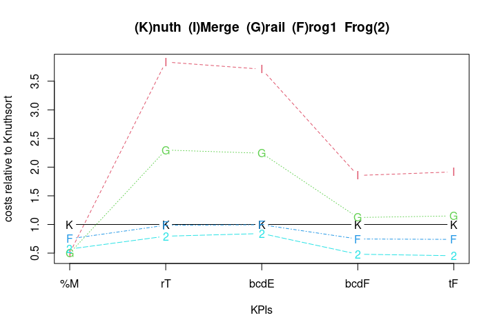

```r
matplot(1:5, t(kn), type="b", pch=c('K','I','G','F','2'), xaxt='n', xlab="KPIs", ylab="costs relative to Knuthsort", main="(K)nuth  (I)Merge  (G)rail  (F)rog1  Frog(2)")
axis(side=1, at=1:5, labels = perflabels()[colnames(kn)])
```

We can also add and subtract using `perfplus` and `perfminus`:

```r
sperf(perfplus(m, rowname = "Total"))
```

```
#>           %RAM  runTime bcdEnergy bcdFootprint tFootprint
#> Total 1.180238 26.35347  621.8874     733.9752   31.10337
```

## Generating data

So far we have used the standard random number generator `runif()` or its parallel cousin `prunif()`. The greeNsort package comes with a rich database of data generator functions that are organized in a `?data.frame`, see `?testdb`. Let’s check the row- and column-names:

```r
dimnames(testdb)
```

```
#> [[1]]
#>  [1] "ascall"            "descall"           "ascdesc"           "descasc"
#>  [5] "asc90rev"          "desc90rev"         "ascnorm"           "descnorm"
#>  [9] "asclog2"           "desclog2"          "ascsqrt"           "descsqrt"
#> [13] "ascdescnorm"       "descascnorm"       "tieshuffle"        "ascshuffle"
#> [17] "descshuffle"       "ascdescshuffle"    "tieascdescshuffle" "ascglobal"
#> [21] "descglobal"        "asclocal"          "desclocal"         "ascdesclocal"
#> [25] "ascwithasc"        "ascwithtie"        "ascwithdesc"       "descwithasc"
#> [29] "descwithtie"       "descwithdesc"      "weekdate"          "weekday"
#> [33] "monthdate"         "monthday"          "permut"            "stable"
#> [37] "stableasc"         "stabledesc"        "stabletie"         "tieboot"
#> [41] "tielog2"           "tiesqrt"           "sample15"          "sample14"
#> [45] "sample13"          "sample12"          "toggle12"          "toggle21"
#> [49] "replic12"          "replic21"          "tieleft1"          "tieleft2"
#> [53] "tieright1"         "tieright2"         "tieperm1"          "tieperm2"
#> [57] "tieall"
#>
#> [[2]]
#>  [1] "name"          "label"         "major"         "minor"         "stable"
#>  [6] "desc"          "code"          "func"          "entropy"       "relentropy"
#> [11] "monotAscFrac"  "strictAscFrac" "spearman"
```

`testdb` has `label`s in `rownames()` and certain features in `colnames()`. Let’s look at descriptions and interpreter code of the functions:

```r
testdb[,c("desc", "code")]
```

```
#>                                                                                   desc
#> ascall                                                                  100% ascending
#> descall                                                                100% descending
#> ascdesc                                              50% ascending then 50% descending
#> descasc                                              50% descending then 50% ascending
#> asc90rev                                           90% ascending, random rest reversed
#> desc90rev                                         90% descending, random rest reversed
#> ascnorm                                  almost ascending with normal disturbance sd=1
#> descnorm                                 almost decending with normal disturbance sd=1
#> asclog2                            almost ascending with normal disturbance sd=log2(n)
#> desclog2                           almost decending with normal disturbance sd=log2(n)
#> ascsqrt                            almost ascending with normal disturbance sd=sqrt(n)
#> descsqrt                           almost decending with normal disturbance sd=sqrt(n)
#> ascdescnorm                  50% ascending then 50% descending with normal disturbance
#> descascnorm                  50% descending then 50% ascending with normal disturbance
#> tieshuffle                                               random shuffle of tied blocks
#> ascshuffle                                          random shuffle of ascending blocks
#> descshuffle                                        random shuffle of descending blocks
#> ascdescshuffle               random shuffle of randomly ascending or descending blocks
#> tieascdescshuffle      random shuffle of randomly tied, ascending or descending blocks
#> ascglobal                            sqrt(N) ascending chunks with sqrt(N) random keys
#> descglobal                          sqrt(N) descending chunks with sqrt(N) random keys
#> asclocal                                      sampled keys in sqrt(N) ascending chunks
#> desclocal                                    sampled keys in sqrt(N) descending chunks
#> ascdesclocal                                 sampled keys in sqrt(N) descending chunks
#> ascwithasc          sqrt(N) ascending chunks with sqrt(N) ascending keys (overlapping)
#> ascwithtie                             sqrt(N) ascending chunks with sqrt(N) tied keys
#> ascwithdesc                      sqrt(N) ascending chunks with sqrt(N) descending keys
#> descwithasc                      sqrt(N) descending chunks with sqrt(N) ascending keys
#> descwithtie                           sqrt(N) descending chunks with sqrt(N) tied keys
#> descwithdesc      sqrt(N) descending chunks with sqrt(N) descending keys (overlapping)
#> weekdate                                             ascending weeks with random times
#> weekday                                               ascending weeks with random days
#> monthdate                                           ascending months with random times
#> monthday                                             ascending months with random days
#> permut                                                               random permuation
#> stable                                              50% sampled then 50% sampled + 0.5
#> stableasc                                        pairs of ascending integers {i,i+0.5}
#> stabledesc                                      pairs of descending integers {i,i+0.5}
#> stabletie                                           sampled {1,2} + ascending decimals
```

[output cut: 61 more lines]

```
#> sample15                                                                                                                        function (n) as.double(sample(1:5, n, TRUE))
#> sample14                                                                                                                        function (n) as.double(sample(1:4, n, TRUE))
#> sample13                                                                                                                        function (n) as.double(sample(1:3, n, TRUE))
#> sample12                                                                                                                        function (n) as.double(sample(1:2, n, TRUE))
#> toggle12                                                                                                                    function (n) rep(as.double(1:2), length.out = n)
#> toggle21                                                                                                                    function (n) rep(as.double(2:1), length.out = n)
#> replic12                                                                                                                    function (n) c(rep(1, n%/%2), rep(2, n - n%/%2))
#> replic21                                                                                                                    function (n) c(rep(2, n%/%2), rep(1, n - n%/%2))
#> tieleft1                                                                                                                                    function (n) c(rep(1, n - 1), 2)
#> tieleft2                                                                                                                                    function (n) c(rep(2, n - 1), 1)
#> tieright1                                                                                                                                   function (n) c(2, rep(1, n - 1))
#> tieright2                                                                                                                                   function (n) c(1, rep(2, n - 1))
#> tieperm1                                                                                                                            function (n) sample(c(2, rep(1, n - 1)))
#> tieperm2                                                                                                                            function (n) sample(c(1, rep(2, n - 1)))
#> tieall                                                                                                                                                function (n) rep(1, n)
```

Let’s pick out those ones, that we have used for the total evaluation in the *greeNsort<sup>®</sup>* innovation report:

```r
D <- c("permut","tielog2","ascall","asclocal","ascglobal")
testdb[D,c("desc", "code")]
```

```
#>                                                        desc
#> permut                                    random permuation
#> tielog2          random sample from log2(N) distinct values
#> ascall                                       100% ascending
#> asclocal           sampled keys in sqrt(N) ascending chunks
#> ascglobal sqrt(N) ascending chunks with sqrt(N) random keys
#>                                                                                                                                                   code
#> permut                                                                                                               function (n) as.double(sample(n))
#> tielog2                                                                                             function (n) as.double(sample(1:log2(n), n, TRUE))
#> ascall                                                                                                                     function (n) as.double(1:n)
#> asclocal                                    function(n, b=ceiling(sqrt(n))) {x <- as.double(sample(n)); Chunksort(x, b=b, direction=1, perf=FALSE); x}
#> ascglobal function(n, b=ceiling(sqrt(n))) {k <- n %/% b; r <- n %% b; k <- if (r) c(rep(b,k), r) else rep(b,k); rep(seq(1, n, b), k) + runif(n, 0, b)}
```

To get randomly permuted numbers from 1 to `N` you can

```r
N <- 7
testdb$func$permut(N)
```

```
#> [1] 6 2 7 1 4 3 5
```

We can also do this progamatically, a picture says more than thousand words:

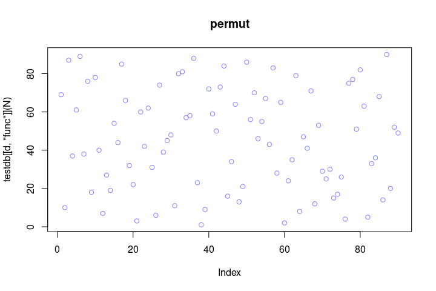

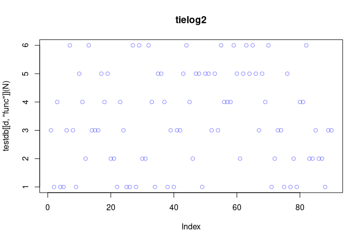

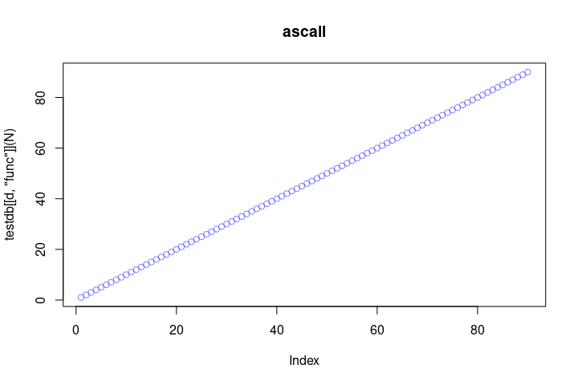

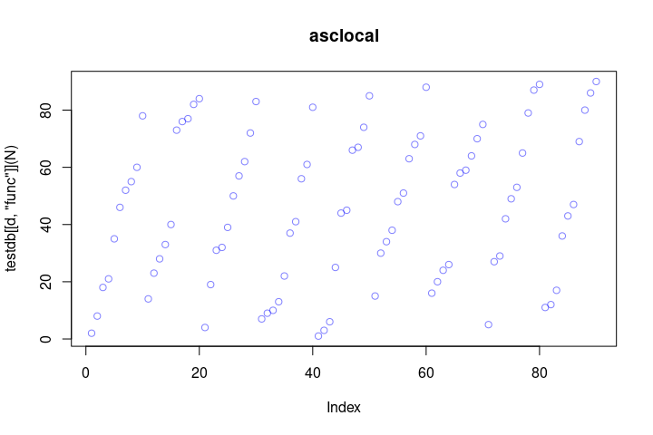

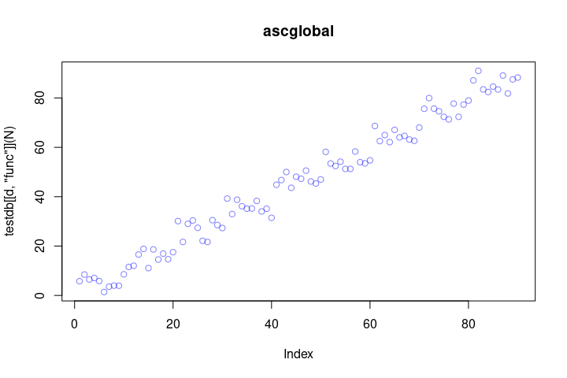

```r
N <- 90
for (d in D)
  plot(testdb[[d,"func"]](N), col=rgb(red=0, green=0, blue=1, alpha=0.5), main=d)
```

We see easily that `permut` is completely unsorted (and has no duplicates), `tielog` has a logarithmic number of unique values and hence a lot of duplicates, `ascall` is perfectly presorted, `asclocal` has `sqrt(N)` locally ascending sequences (no duplicates, the type of data *Timsort* likes) and `ascglobal` has globally ascending clusters, each locally unsorted (no duplicates).

## Working with algorithms

The algorithms in the greeNsort package are organized in a `?data.frame`, see `?algodb`. Each algorithms is described in a row across several feature columns:

```r
dimnames(algodb)
```

```
#> [[1]]
#>   [1] "Sel"       "Sel2"      "Ins"       "SIns"      "RIns"      "UIns"
#>   [7] "WIns"      "VIns"      "MIns"      "NIns"      "aMd"       "bfprt"
#>  [13] "pick"      "quick"     "zick"      "zack"      "zuck"      "zuckB"
#>  [19] "duck"      "duckB"     "quickpl"   "quickpr"   "zackpl"    "zackpr"
#>  [25] "dotnetpt"  "quickpt"   "zackpt"    "zuckpt"    "zuckptB"   "duckpt"
#>  [31] "duckptB"   "Lomuto"    "Quick1"    "Quick2"    "Quick3"    "Dupi"
#>  [37] "Trick"     "Quick2B"   "Plug"      "Pug"       "Slick"     "Sick"
#>  [43] "BFPRT"     "Pick"      "RQuick2"   "RQuick2B"  "SQuick2"   "SQuick2B"
#>  [49] "Chick"     "Zock"      "Zack"      "ZackB"     "Zuck"      "ZuckA"
#>  [55] "ZuckB"     "ZuckD"     "Duck"      "DuckB"     "Zick"      "Copy"
#>  [61] "Noco"      "Simpl"     "Bime"      "BimeB"     "Knuth"     "KnuthA"
#>  [67] "Kata"      "KataA"     "KataB"     "Knuth3"    "Knuth4"    "Kata3"
#>  [73] "Kata4"     "GKnuth"    "TKnuth"    "Croco"     "Croco3"    "Croco4"
#>  [79] "Kroco3"    "Kroco4"    "Inin"      "Nini"      "Frog0"     "Gecko0"
```

[output cut: 25 more lines]

There are algorithms for different tasks, and some of them are stable (keep the original order in case of tied keys):

```r
table(algodb$task, algodb$stable, useNA= "ifany")[c("MEDIAN","SELECT","SORT","sort"),]
```

```
#>
#>          FALSE TRUE
#>   MEDIAN     1    0
#>   SELECT     6    0
#>   SORT      36   86
#>   sort       2    8
```

The package as an (approximate) MEDIAN algorithm, some SELECTion algorithms, many SORTing algorithms. The lowercase ‘sort’ algorithms are only suitable for very small datasets because they scale $\mathcal{O}(N^2)$; they are used for the recursion leaves of the SORT algorithms, and are made available in R only for testing purposes.

### Stable Sorting

```r
as.list(subset(algodb
      , task=="SORT"              # non-small sorting algorithms
       & stable                   # that are stable
       & class == "S&M"           # have class Split&Merge
       & log == 2                 # are binary
       & !adapt_asc=="tuned"      # are not tuned for presorted data
       & avoid_bm=="no"           # do not avoid branch mispredictions
       & !parallel                # are not parallel
       & !varying                 # are not varying
       , c("label","name"         # columns selected: "label" and "names"
       )))
```

```
#> $label
#>  [1] "Copy"      "Noco"      "Bime"      "Knuth"     "Kata"      "GKnuth"
#>  [7] "TKnuth"    "Croco"     "Inin"      "Nini"      "Frog0"     "Gecko0"
#> [13] "Gecko1"    "Frog1"     "Frog4"     "Frog5"     "IMerge"    "Grail"
#> [19] "Grailsqrt" "Sqrt"      "Walk"      "Jump"      "MKnuth"    "NKnuth"
#>
#> $name
#>  [1] "Copysort"   "Nocosort"   "Bimesort"   "Knuthsort"  "Katasort"   "GKnuthsort"
#>  [7] "TKnuthsort" "Crocosort"  "Ininsort"   "Ninisort"   "Frogsort0"  "Geckosort0"
#> [13] "Geckosort1" "Frogsort1"  "Frogsort4"  "Frogsort5"  "IMergesort" "Grailsort"
#> [19] "Grailsqrt"  "Sqrtsort"   "Walksort"   "Jumpsort"   "MKnuthsort" "NKnuthsort"
```

```r
n <- 2^18
x <- runif(n)
A <- c("Knuth","Bime","Frog1","Frog2","Frog3","Walk","Sqrt","Grail")
names(A) <- algodb[A, "name"]
R <- 1:50
names(R) <- R
# we collect the results in a A x D matrix of list elements
L <- lapply(R, function(r){
  #cat("r=", r, "\n", sep="")
  set.seed(r)
  x <- testdb$func$permut(n)
  do.call("rbind", lapply(
      sample(A)  # random order of algorithms for each replication
    , function(a){
    y <- x[]
    perf(algodb[[a,"func"]](y))
  }
  ))[names(A),]  # undo random order
})
rm(x)
RAM <- do.call("rbind", lapply(L,function(l)l[,"%RAM"]))
runTime <- do.call("rbind", lapply(L,function(l)l[,"runTime"]))
Energy <- do.call("rbind", lapply(L,function(l)l[,"bcdEnergy"]))
eFootprint <- do.call("rbind", lapply(L,function(l)l[,"bcdFootprint"]))
runTime <- runTime/min(apply(runTime, 2, median))
Energy <- Energy/min(apply(Energy, 2, median))
eFootprint <- eFootprint/min(apply(eFootprint, 2, median))
```

```r
cbind(
  "%RAM"    = apply(RAM       , 2, median)
, runTime   = apply(runTime   , 2, median)
, Energy    = apply(Energy    , 2, median)
, eFootprint= apply(eFootprint, 2, median)
)
```

```
#>               %RAM  runTime   Energy eFootprint
#> Knuthsort 2.000000 1.247271 1.135479   1.987088
#> Bimesort  2.000000 1.314111 1.209578   2.116761
#> Frogsort1 1.500000 1.224633 1.173959   1.540822
#> Frogsort2 1.142857 1.000000 1.000000   1.000000
#> Frogsort3 1.125000 1.177798 1.080210   1.063331
#> Walksort  1.007824 1.471023 1.432653   1.263379
#> Sqrtsort  1.002932 1.795841 1.741757   1.528505
#> Grailsort 1.000000 1.988757 1.830495   1.601683
```

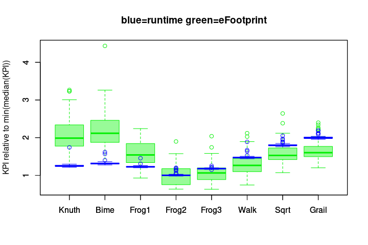

```r
boxplot(eFootprint, names=A, border="green2", col="palegreen", main="blue=runtime green=eFootprint", ylab="KPI relative to min(median(KPI))")
boxplot(runTime, names=A, border="blue", col="lightskyblue", add=TRUE)
```

### Tuning %RAM

Let’s check for an optimal buffer fraction for *Frogsort2*.

```r
n <- 2^18
E <- sample(seq(20, 2, by=-0.05))
P <- 1/E
names(P) <- paste("1/", E, sep="")
M <- do.call("rbind", lapply(P
    , function(p){
      #cat("p=", p, "\n", sep="")
    perf(Frogsort2(runif(n), p=p))
  }
))
M <- M[order(P),]
E <- E[order(P)]
P <- P[order(P)]
srunTime <- supsmu(P, M[,"runTime"])$y
sEnergy <- supsmu(P, M[,"bcdEnergy"])$y
sFootprint <- supsmu(P, M[,"bcdFootprint"])$y
runTime <- M[,"runTime"] / min(srunTime)
Energy <- M[,"bcdEnergy"] / min(sEnergy)
Footprint <- M[,"bcdFootprint"] / min(sFootprint)
srunTime <- srunTime / min(srunTime)
sEnergy <- sEnergy / min(sEnergy)
sFootprint <- sFootprint / min(sFootprint)
```

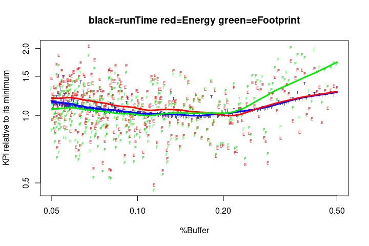

```r
matplot(P, cbind(runTime, Energy, Footprint), col=c("blue","red","green2"), log="xy", cex=0.5, pch=c("T","E","F"), xlab="%Buffer", ylab="KPI relative to its minimum", main="black=runTime red=Energy green=eFootprint")
matlines(P,cbind(srunTime, sEnergy, sFootprint), col=c("blue","red","green2"), lty=1, lwd=3)
```

### Adaptive Sorting

Adaptivity for presorted data is coded in `algodb$adapt_asc`:

```r
table(algodb$adapt_asc, useNA="ifany")
```

```
#>
#>  hard    no  none  soft tuned  <NA>
#>    30     1     2    93    25     2
```

Most sorting algorithms (*soft*) behave somewhat adaptive although this is not designed into the algorithm, some algorithms are automatically adaptive by design (*hard*), some algorithms are *tuned* to be adaptive accepting some trade-off (often denoted `*sortA`), and few are not adaptive at all (*none*). `NA` represents algorithms where this attribute is unknown or inappropriate. Let’s look at the *hard* and *tuned* ones:

```r
A <- c("Knuth", algodb$label[algodb$task=="SORT" & algodb$adapt_asc %in% c("hard","tuned")])
split(A, algodb[A,"adapt_asc"])
```

```
#> $hard
#>  [1] "Croco"  "Inin"   "Nini"   "Frog0"  "Gecko0" "Gecko1" "Frog1"  "Frog1B" "Frog2"
#> [10] "Frog2B" "Frog3"  "Frog3B" "Frog6"  "Frog4"  "Frog5"  "VFrog1" "MFrog2" "NFrog2"
#> [19] "PFrog0" "PFrog1" "PFrog2" "PFrog3"
#>
#> $soft
#> [1] "Knuth"
#>
#> $tuned
#>  [1] "ZuckA"   "Duck"    "DuckB"   "KnuthA"  "KataA"   "Frog1A"  "Frog2A"  "Omit"
#>  [9] "Octo"    "Squid1"  "Squid2"  "VKnuthA" "VFrog1A" "PDuck"   "PDuckB"  "Pdq"
#> [17] "PdqB"    "Tim"     "Peek"    "Power"   "Power4"
```

Here are some stored measurements for a subset of those (AMD® Ryzen 7 pro 6850, 8 physical cores):

This was measured with the following code, try it out on your machine:

```r
A <- c("Knuth","Omit","Octo","Gecko1", "Frog1","Frog1A","Squid1","Frog2","Frog2A","Squid2","PFrog1","PFrog2","Tim","Peek","Power")
names(A) <- A
D <- c("permut", "asclocal", "desclocal", "ascglobal", "descglobal", "ascall", "descall")
names(D) <- D
n <- 2^25
#n4 <- n/4
# we collect the results in a A x D matrix of list elements
M <- do.call("cbind", lapply(D, function(d){
  cat("d=", d, "\n", sep="")
  x <- testdb[[d,"func"]](n)
  P <- lapply(A, function(a){
    cat("  a=", a, "\n", sep="")
    #if (algodb[[a,"varying"]]){
    #  y <- num2str(e[1:n4])
    #}else{
      y <- x[]
    #}
    Sys.sleep(1)  # cool down CPU for fair TURBO
    perf(algodb[[a,"func"]](y))
  })
  P
}))
T <- function(x)cbind(x, "ALL"=rowMeans(cbind(x, x[,"permut"])), ASC=rowMeans(x[,c("permut","asclocal","ascglobal","ascall")]))
runTime <- T(apply(M,1:2,function(i)i[[1]][,"runTime"]))
Energy <- T(apply(M,1:2,function(i)i[[1]][,"bcdEnergy"]))
eFootprint <- T(apply(M,1:2,function(i)i[[1]][,"bcdFootprint"]))
dput(runTime)
dput(Energy)
dput(eFootprint)
```

Let’s look at runTime normalized by *Knuthsort* at randomly permuted data:

```r
round(t(t(runTime)/runTime["Knuth","permut"]), 3)
```

```
#>        permut asclocal desclocal ascglobal descglobal ascall descall   ALL   ASC
#> Knuth   1.000    0.580     0.776     0.549      0.544  0.167   0.326 0.618 0.574
#> Omit    1.027    0.572     0.704     0.545      0.548  0.013   0.283 0.590 0.539
#> Octo    0.986    0.574     0.567     0.544      0.545  0.014   0.020 0.529 0.529
#> Gecko1  0.991    0.653     0.633     0.511      0.510  0.180   0.161 0.579 0.584
#> Frog1   0.981    0.589     0.690     0.510      0.526  0.103   0.215 0.574 0.546
#> Frog1A  0.964    0.582     0.681     0.498      0.537  0.076   0.234 0.567 0.530
#> Squid1  0.969    0.559     0.589     0.515      0.537  0.077   0.083 0.537 0.530
#> Frog2   0.717    0.433     0.589     0.400      0.547  0.061   0.352 0.477 0.403
#> Frog2A  0.721    0.420     0.597     0.411      0.549  0.042   0.362 0.478 0.399
#> Squid2  0.722    0.419     0.438     0.453      0.512  0.043   0.047 0.419 0.409
#> PFrog1  0.164    0.132     0.142     0.104      0.117  0.078   0.099 0.125 0.119
#> PFrog2  0.156    0.129     0.147     0.117      0.127  0.083   0.118 0.129 0.121
#> Tim     1.120    0.640     0.621     0.499      0.635  0.009   0.017 0.583 0.567
#> Peek    1.106    0.641     0.649     0.548      0.608  0.028   0.055 0.593 0.581
#> Power   1.085    0.647     0.644     0.557      0.588  0.029   0.034 0.584 0.579
```

There are two totals, `ASC` is the average cost over the `permut` and `asc*` datasets, `ALL` is the average cost over the `permut` (twice) and `asc*` and `desc*` datasets. By convention sorting is rather ascending, hence we consider `ASC` practically more relevant, `ALL` is included to provide a benchmark for bi-adaptive algorithms (*Octo*, *Gecko1*, *Squid1*, *Squid2*, *Tim*, *Peek*, *Power*). While *Timsort*, *Peeksort* and *Powersort* excel at presorted data, they pay a tuning price on randomly permuted data. In a mixed portfolio of tasks such as `ASC` they play in the same league like a simple *Knuthsort*. The simple un-tuned *Frog2* algorithm is a clear speed-winner. The parallel `PFrog1` achieved a speedup of 6x with permuted data, very little speedup with perfectly presorted data, and 5x for `ASC`. `Frogsort2` loses its speed advantage over `Frogsort1` when parallelized. Note that *Timsort* and *Powersort* are inherently serial.

Let’s look at *Energy* normalized by *Knuthsort* at randomly permuted data:

```r
round(t(t(Energy)/Energy["Knuth","permut"]), 3)
```

```
#>        permut asclocal desclocal ascglobal descglobal ascall descall   ALL   ASC
#> Knuth   1.000    0.479     0.643     0.461      0.459  0.145   0.285 0.559 0.521
#> Omit    1.029    0.465     0.598     0.458      0.450  0.010   0.250 0.536 0.490
#> Octo    0.813    0.469     0.476     0.459      0.459  0.010   0.015 0.439 0.438
#> Gecko1  0.803    0.540     0.524     0.427      0.430  0.165   0.145 0.480 0.484
#> Frog1   0.798    0.484     0.570     0.419      0.438  0.089   0.192 0.474 0.448
#> Frog1A  0.793    0.472     0.581     0.416      0.448  0.061   0.211 0.472 0.435
#> Squid1  0.793    0.466     0.482     0.426      0.443  0.063   0.067 0.442 0.437
#> Frog2   0.610    0.380     0.509     0.335      0.464  0.056   0.316 0.410 0.345
#> Frog2A  0.624    0.369     0.520     0.340      0.477  0.036   0.325 0.415 0.343
#> Squid2  0.633    0.381     0.399     0.390      0.446  0.036   0.040 0.370 0.360
#> PFrog1  0.268    0.209     0.229     0.173      0.204  0.118   0.167 0.205 0.192
#> PFrog2  0.260    0.215     0.245     0.154      0.206  0.095   0.189 0.203 0.181
#> Tim     0.946    0.539     0.537     0.408      0.532  0.006   0.017 0.491 0.475
#> Peek    0.909    0.534     0.544     0.464      0.512  0.019   0.046 0.492 0.482
#> Power   0.918    0.541     0.539     0.471      0.504  0.022   0.026 0.492 0.488
```

Let’s look at eFootprint normalized by *Knuthsort* at randomly permuted data:

```r
round(t(t(eFootprint)/eFootprint["Knuth","permut"]), 3)
```

```
#>        permut asclocal desclocal ascglobal descglobal ascall descall   ALL   ASC
#> Knuth   1.000    0.479     0.643     0.461      0.459  0.145   0.285 0.559 0.521
#> Omit    1.029    0.465     0.598     0.458      0.450  0.010   0.250 0.536 0.490
#> Octo    0.813    0.469     0.476     0.459      0.459  0.010   0.015 0.439 0.438
#> Gecko1  0.602    0.405     0.393     0.321      0.323  0.124   0.109 0.360 0.363
#> Frog1   0.599    0.363     0.427     0.314      0.328  0.067   0.144 0.355 0.336
#> Frog1A  0.595    0.354     0.436     0.312      0.336  0.046   0.158 0.354 0.327
#> Squid1  0.594    0.350     0.361     0.320      0.332  0.047   0.050 0.331 0.328
#> Frog2   0.349    0.217     0.291     0.192      0.265  0.032   0.180 0.234 0.197
#> Frog2A  0.357    0.211     0.297     0.195      0.273  0.021   0.186 0.237 0.196
#> Squid2  0.362    0.217     0.228     0.223      0.255  0.021   0.023 0.211 0.206
#> PFrog1  0.201    0.157     0.172     0.130      0.153  0.088   0.125 0.153 0.144
#> PFrog2  0.156    0.129     0.147     0.093      0.123  0.057   0.114 0.122 0.109
#> Tim     0.709    0.404     0.403     0.306      0.399  0.004   0.013 0.368 0.356
#> Peek    0.682    0.401     0.408     0.348      0.384  0.014   0.034 0.369 0.361
#> Power   0.689    0.406     0.405     0.353      0.378  0.016   0.020 0.369 0.366
```

Regarding *eFootprints* the differences are more pronounced, *Timsort*, *Peeksort* and *Powersort* win over *Knuthsort*, but not over the *greeNsort<sup>®</sup>* algorithms. *Frogsort2* emerges as a clear winner, particularly if parallelized.

### Unstable Sorting

```r
as.list(subset(algodb
      , task=="SORT"              # non-small sorting algorithms
       & class == "P&P"           # that have class Partition&Pool
       & !stable                  # are stable
       & log == 2                 # are binary
       & !parallel                # are not parallel
       & !varying                 # are not varying
       , c("label","name"         # columns selected: "label" and "names"
       )))
```

```
#> $label
#>  [1] "Lomuto"  "Quick1"  "Quick2"  "Quick3"  "Quick2B" "Plug"    "Pug"     "Slick"
#>  [9] "Sick"    "BFPRT"   "Pick"    "Chick"   "Zock"    "Zack"    "ZackB"   "Zuck"
#> [17] "ZuckA"   "ZuckB"   "ZuckD"   "Duck"    "DuckB"   "Zick"    "Pdq"     "PdqB"
#>
#> $name
#>  [1] "Lomutosort"  "Quicksort1"  "Quicksort2"  "Quicksort3"  "Quicksort2B"
#>  [6] "Plugsort"    "Pugsort"     "Slicksort"   "Sicksort"    "BFPRTsort"
#> [11] "Picksort"    "Chicksort"   "Zocksort"    "Zacksort"    "ZacksortB"
#> [16] "Zucksort"    "ZucksortA"   "ZucksortB"   "ZucksortD"   "Ducksort"
#> [21] "DucksortB"   "Zicksort"    "Pdqsort"     "PdqsortB"
```

```r
n <- 2^18
x <- runif(n)
A <- c("Quick2","Quick3","Dupi","Quick2B","Zack","ZackB")
names(A) <- algodb[A, "name"]
R <- 1:50
names(R) <- R
# we collect the results in a A x D matrix of list elements
L <- lapply(R, function(r){
  #cat("r=", r, "\n", sep="")
  set.seed(r)
  x <- testdb$func$tiesqrt(n)
  do.call("rbind", lapply(
      sample(A)  # random order of algorithms for each replication
    , function(a){
    y <- x[]
    perf(algodb[[a,"func"]](y))
  }
  ))[names(A),]  # undo random order
})
rm(x)
RAM <- do.call("rbind", lapply(L,function(l)l[,"%RAM"]))
runTime <- do.call("rbind", lapply(L,function(l)l[,"runTime"]))
Energy <- do.call("rbind", lapply(L,function(l)l[,"bcdEnergy"]))
runTime <- runTime/min(apply(runTime, 2, median))
Energy <- Energy/min(apply(Energy, 2, median))
```

```r
cbind(
  "%RAM"    = apply(RAM       , 2, median)
, runTime   = apply(runTime   , 2, median)
, Energy    = apply(Energy    , 2, median)
)
```

```
#>             %RAM  runTime   Energy
#> Quicksort2     1 3.246935 3.191883
#> Quicksort3     1 2.786826 2.866900
#> Dupisort       1 3.084532 3.294350
#> Quicksort2B    1 1.419207 1.347239
#> Zacksort       1 2.737884 2.888423
#> ZacksortB      1 1.000000 1.000000
```

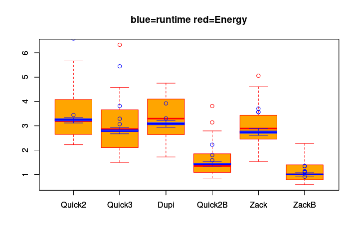

```r
boxplot(Energy, names=A, border="red", col="orange", main="blue=runtime red=Energy")
boxplot(runTime, names=A, border="blue", col="lightskyblue", add=TRUE)
```

### Parallel Sorting

Parallel sorting can save energy, on single user machines because the CPU can quicker return to lower energy states.

The data was create with this code:

```r
situtation <- "insitu"
#situtation <- "exsitu"
n <- 2^27
x <- prunif(n)
A <- c("PKnuth","PQuick2B","PFrog0", "PFrog2")
names(A) <- A
P <- 1:32
names(P) <- P
# we collect the results in a A x P matrix of list elements
M <- do.call("cbind", lapply(A, function(a){
  cat("a=", a, "\n", sep="")
  lapply(P, function(p){
    cat("  p=", p, "\n", sep="")
    y <- x[]
    Sys.sleep(1)  # cool down CPU for fair TURBO
    perf(algodb[[a,"func"]](y, threads=p, situation=situtation))
  })
}))
runTime <- apply(M,1:2,function(i)i[[1]][,"runTime"])
Energy <- apply(M,1:2,function(i)i[[1]][,"bcdEnergy"])
eFootprint <- apply(M,1:2,function(i)i[[1]][,"bcdFootprint"])
dput(runTime)
dput(Energy)
dput(eFootprint)
rm(x)
```

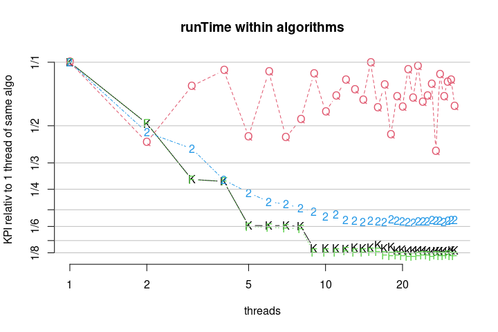

```r
matplot(1:32, t(t(runTime)/runTime["1",]), pch=c("K","Q","F","2"), type="b", log="xy", main="runTime within algorithms", xlab="threads", ylab="KPI relativ to 1 thread of same algo", axes=FALSE)
axis(1); axis(2, at=1/(1:8), labels = paste("1/", 1:8, sep="")); abline(h=1/(1:8), col="gray")
```

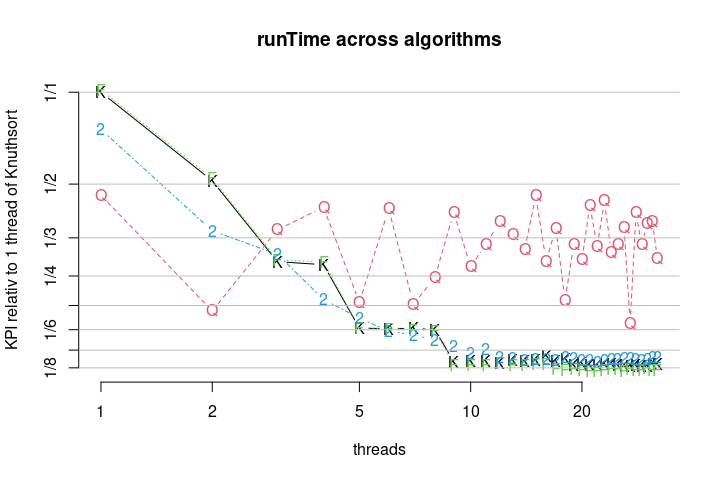

```r
matplot(1:32, runTime/runTime["1","PKnuth"], pch=c("K","Q","F","2"), type="b", log="xy", main="runTime across algorithms", xlab="threads", ylab="KPI relativ to 1 thread of Knuthsort", axes=FALSE)
axis(1); axis(2, at=1/(1:8), labels = paste("1/", 1:8, sep="")); abline(h=1/(1:8), col="gray")
```

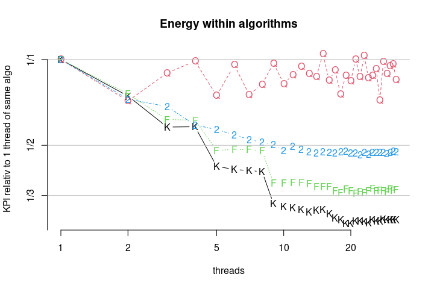

```r
matplot(1:32, t(t(Energy)/Energy["1",]), pch=c("K","Q","F","2"), type="b", log="xy", main="Energy within algorithms", xlab="threads", ylab="KPI relativ to 1 thread of same algo", axes=FALSE)
axis(1); axis(2, at=1/(1:8), labels = paste("1/", 1:8, sep="")); abline(h=1/(1:8), col="gray")
```

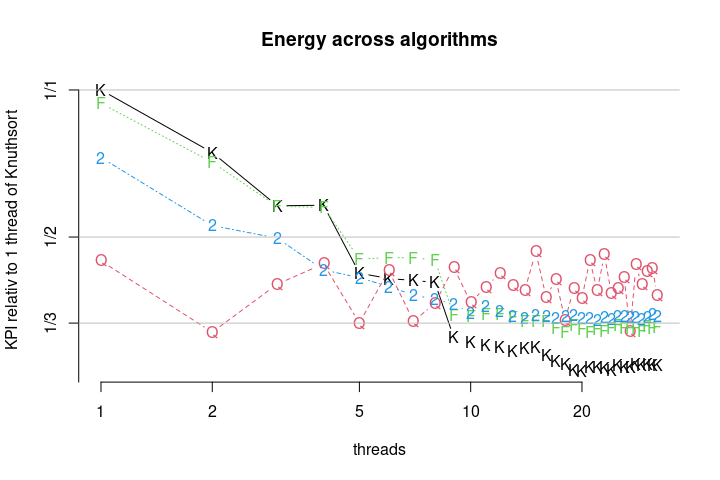

```r
matplot(1:32, Energy/Energy["1","PKnuth"], pch=c("K","Q","F","2"), type="b", log="xy", main="Energy across algorithms", xlab="threads", ylab="KPI relativ to 1 thread of Knuthsort", axes=FALSE)
axis(1); axis(2, at=1/(1:8), labels = paste("1/", 1:8, sep="")); abline(h=1/(1:8), col="gray")
```

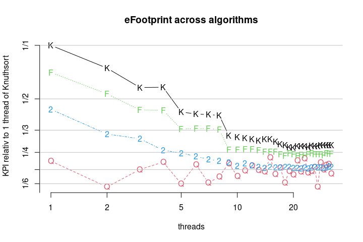

```r
matplot(1:32, eFootprint/eFootprint["1","PKnuth"], pch=c("K","Q","F","2"), type="b", log="xy", main="eFootprint across algorithms", xlab="threads", ylab="KPI relativ to 1 thread of Knuthsort", axes=FALSE)
axis(1); axis(2, at=1/(1:8), labels = paste("1/", 1:8, sep="")); abline(h=1/(1:8), col="gray")
```

### Medians and Selection

Median and Selection algorithms can be used to calculate the 50% percentile, so let’s look at them together. The greeNsort package has

```r
algodb[algodb$task %in% c("MEDIAN", "SELECT"),c("name","best","average","worst")]
```

```
#>               name best average    worst
#> aMd   approxMedian    N       N        N
#> zick    Zickselect    N       N N*log(N)
#> zack    Zackselect    N       N       N²
#> zuck    Zuckselect    N       N       N²
#> zuckB  ZuckselectB    N       N       N²
#> duck    Duckselect    N       N       N²
#> duckB  DuckselectB    N       N       N²
```

The median of the sequence `1:100` is calculated in R as `median(1:100)` = 50.5, which in the even case is the average of the two mid-most values `mean(50:51)`. A generalization is available as `quantile(1:100, probs=c(0.5, 0.6))` = 50.5, 60.4. We can force to return an existing value by `quantile(1:100, probs=0.5, type=1)` = 50 which is biased downwards and give the value at position at position 50, not 51 (R counts from 1, unlike C which counts from 0).

Selection algorithms typically return the value at a specified position in a hypothetically sorted set without incurring the cost of full sorting. Take the following example

```r
x <- testdb$func$tielog2(100)
y <- sort(x)
t(y)
```

```
#>      [,1] [,2] [,3] [,4] [,5] [,6] [,7] [,8] [,9] [,10] [,11] [,12] [,13] [,14]
#> [1,]    1    1    1    1    1    1    1    1    1     1     1     1     1     1
#>      [,15] [,16] [,17] [,18] [,19] [,20] [,21] [,22] [,23] [,24] [,25] [,26] [,27]
#> [1,]     1     1     1     1     1     1     1     1     1     1     2     2     2
#>      [,28] [,29] [,30] [,31] [,32] [,33] [,34] [,35] [,36] [,37] [,38] [,39] [,40]
#> [1,]     2     2     2     2     2     2     2     2     2     2     3     3     3
#>      [,41] [,42] [,43] [,44] [,45] [,46] [,47] [,48] [,49] [,50] [,51] [,52] [,53]
#> [1,]     3     3     3     3     3     3     3     3     3     4     4     4     4
#>      [,54] [,55] [,56] [,57] [,58] [,59] [,60] [,61] [,62] [,63] [,64] [,65] [,66]
#> [1,]     4     4     4     4     4     4     4     4     4     5     5     5     5
#>      [,67] [,68] [,69] [,70] [,71] [,72] [,73] [,74] [,75] [,76] [,77] [,78] [,79]
#> [1,]     5     5     5     5     5     5     5     5     5     5     5     5     5
#>      [,80] [,81] [,82] [,83] [,84] [,85] [,86] [,87] [,88] [,89] [,90] [,91] [,92]
#> [1,]     5     5     5     5     5     5     5     6     6     6     6     6     6
#>      [,93] [,94] [,95] [,96] [,97] [,98] [,99] [,100]
#> [1,]     6     6     6     6     6     6     6      6
```

The 50th value, at position 50 is 4. A famous deterministic algorithm for finding this at lower cost is *BFPRT*, that of Blum, Floyd, Pratt, Rivest & Tarjan (1973), which uses a *Median of Medians* sub-algorithm.

```r
y <- x[]
v <- BFPRTselect(y, 50)
v
```

```
#> [1] 4
#> attr(,"perf")
#>               n b p t size      secs base core unco dram
#> BFPRTselect 100 8 1 1    1 3.927e-06    0    0    0    0
```

It returns 4 together with an attribute `attr(, "perf")` holding the measurement. We can seperate the two by

```r
as.vector(v)
```

```
#> [1] 4
```

and

```r
rawperf(v)
```

```
#>               n b p t size      secs base core unco dram
#> BFPRTselect 100 8 1 1    1 3.927e-06    0    0    0    0
```

or directly

```r
sperf(v)
```

```
#>             %RAM   runTime bcdEnergy bcdFootprint tFootprint
#> BFPRTselect    1 3.927e-06         0            0  3.927e-06
```

*greeNsort<sup>®</sup>* discovered that *BFPRT* does unnecessary work, which can be avoided by using the *Medians of Medians* sub-algorithm to find an *approximate median* and plugging it as pivot in a classic *Quickselect*, see below. Here we go:

```r
as.vector(approxMedian(as.double(1:100)))
```

```
#> [1] 48
```

This version does not change its input and needs only 20% buffer:

```r
as.vector(approxMedian(as.double(1:100), situation = "exsitu"))
```

```
#> [1] 53
```

And here is *Pickselect* which uses `approxMedian`:

```r
as.vector(Pickselect(as.double(1:100)))
```

```
#> [1] 50
```

The symmetric *greeNsort<sup>®</sup>* version *Zickselect* is more informative: at the same costs it properly handles ties and returns the leftmost and rightmost position of elements tied with the specified position

```r
y <- x
k <- as.vector(Zickselect(y))
k
```

```
#> [1] 50 62
```

To get the value itself take the k-th element from `y`:

```r
y[k[1]]
```

```
#> [1] 4
```

This works because Zickselect’s input has been properly *partially* sorted:

```r
y
```

```
#>   [1] 1 1 2 2 2 3 3 3 3 1 2 1 1 1 1 2 2 1 1 1 2 2 2 2 1 3 1 2 1 3 1 1 3 3 1 1 1 3 3 1
#>  [41] 1 1 2 3 1 1 1 2 3 4 4 4 4 4 4 4 4 4 4 4 4 4 5 5 5 5 5 5 5 5 5 5 5 5 5 5 5 5 5 5
#>  [81] 5 5 5 5 5 5 6 6 6 6 6 6 6 6 6 6 6 6 6 6
```

For a visualization of the difference to *BFPRTselect* and *Pickselect* see

```r
set.seed(2)
example(Zickselect)
```

```
#>
#> Zckslc> n <- getOption("greensort_example_size")
#>
#> Zckslc> x <- testdb$func$tiesqrt(n)
#>
#> Zckslc> k <- n%/%2
#>
#> Zckslc> y <- x[]; p <- Pickselect(y, k)
#>
#> Zckslc> z <- x[]; v <- Zickselect(z, k)
#>
#> Zckslc> plot(sort(x), main="fully sorted data")
```

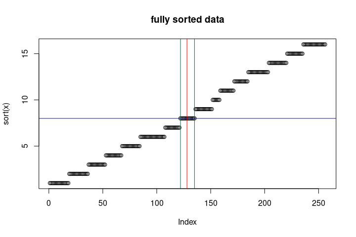

```
#>
#> Zckslc> abline(h=p, col="blue")
#>
#> Zckslc> abline(v=v, col=greensort_color)
#>
#> Zckslc> abline(v=k, col="red")
#>
#> Zckslc> plot(y, main="partially sorted data (Pickselect)")
```

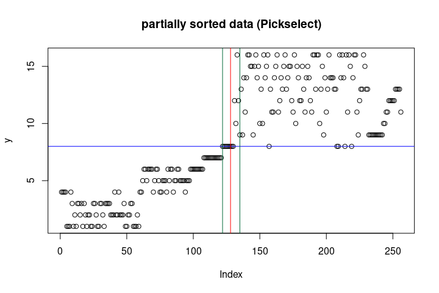

```
#>
#> Zckslc> abline(h=p, col="blue")
#>
#> Zckslc> abline(v=v, col=greensort_color)
#>
#> Zckslc> abline(v=k, col="red")
#>
#> Zckslc> plot(z, main="partially sorted data (Zickselect)")
```

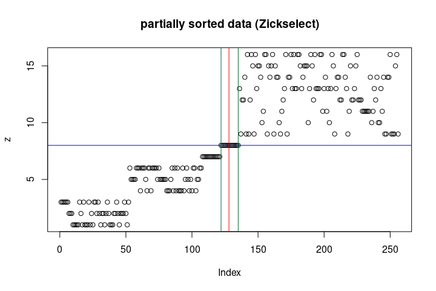

```
#>
#> Zckslc> abline(h=p, col="blue")
#>
#> Zckslc> abline(v=v, col=greensort_color)
#>
#> Zckslc> abline(v=k, col="red")
```

It is known that the classic probabilistic *Quickselect* is faster than the deterministic *BFPRT*. The symmetric *Zackselect* improves up this with proper tie handling and the more informative return values. *ZuckselectB* is a version tuned to avoid branch-misprediction.

Let’s measure R’s `median` and `quantile` functions:

```r
n <- 2^27
k1 <- n %/% 2
k2 <- k1 + 1
x <- testdb$func$tielog2(n)
p <- perfnow()
m <- median(x)
pm <- sperf(perfthen(p, rowname = "median", n=n, b=8, p=1, t=1, size = 1))
p <- perfnow()
q <- quantile(x, 0.5, type=1)
pq <- sperf(perfthen(p, rowname = "quantile", n=n, b=8, p=1, t=1, size = 1))
rbind(pm,pq)
```

```
#>          %RAM runTime bcdEnergy bcdFootprint tFootprint
#> median      1   2.826  81.74121     81.74121      2.826
#> quantile    1   3.535 101.21536    101.21536      3.535
```

Now let’s measure some algorithms of the greeNosrt package. approxMedian with `situation = "exsitu"` protects its input, all other calls don’t:

```r
l <- list(
  {          approxMedian(x, situation = "exsitu")}
, {y <- x[]; approxMedian(y) } # default: , situation = "insitu")
, {y <- x[]; BFPRTselect(y) }
, {y <- x[]; Pickselect(y) }
, {y <- x[]; Zickselect(y) }
, {y <- x[]; Quickselect(y) }
, {y <- x[]; Zackselect(y) }
, {y <- x[]; ZuckselectB(y) }
, {y <- x[]; p1 <- rawperf(ZuckselectB(y, k1)); p2 <- rawperf(ZuckselectB(y, k2));
   i <- c("secs","base","core","unco","dram"); p1[,i] <- p1[,i]+p2[,i]; p1}
, {y <- x[]; ZuckpartB(y, partial= c(k1,k2)) }
)
```

Let’s take the names from the measurement, and show the results without the measurement:

```r
names(l) <- sapply(l, function(x){rownames(rawperf(x))})
lapply(l, as.vector)[-c(length(l), length(l)-1)]
```

```
#> $approxMedian
#> [1] 14
#>
#> $approxMedian
#> [1] 14
#>
#> $BFPRTselect
#> [1] 14
#>
#> $Pickselect
#> [1] 14
#>
#> $Zickselect
#> [1] 64616658 69586111
#>
#> $Quickselect
#> [1] 14
#>
#> $Zackselect
#> [1] 64616658 69586111
#>
#> $ZuckselectB
#> [1] 64616658 69586111
```

Some of the functions return the median 14, however the `Z*select` functions return more informative the range of the positions that are tied to the median. This can easily verified by

```r
c(diff(l[["Zickselect"]])+1, sum(x==m))
```

```
#> [1] 4969454 4969454
```

Let’s measure allocating plus copying to put the results better in context:

```r
e <- perfnow()
y <- x[]
e <- sperf(perfthen(e, rowname = "alloc+copy", n=n, b=8, p=1, t=1, size = 1))
r <- rbind(e, pm, pq, do.call("rbind", lapply(l, sperf)))
r <- data.frame(worst=algodb$worst[match(rownames(r), algodb$name)], r)
r["alloc.copy","worst"] <- "N"
r["median","worst"] <- "N²"
r["quantile","worst"] <- "N²"
rownames(r)[4:5] <- c("approxMedian (exsitu)","approxMedian (insitu)")
rownames(r)[11:12] <- c("ZuckselectB (1x)","ZuckselectB (2x)")
colnames(r)[2] <- "%RAM"
r[order(r$bcdEnergy, decreasing = TRUE),]
```

```
#>                          worst %RAM   runTime bcdEnergy bcdFootprint tFootprint
#> BFPRTselect           N*log(N)  1.0 3.0653201 101.57966    101.57966  3.0653201
#> quantile                    N²  1.0 3.5350000 101.21536    101.21536  3.5350000
#> Pickselect            N*log(N)  1.0 2.6203346  82.58147     82.58147  2.6203346
#> median                      N²  1.0 2.8260000  81.74121     81.74121  2.8260000
#> Zickselect            N*log(N)  1.0 2.7461702  72.18906     72.18906  2.7461702
#> approxMedian (exsitu)        N  1.2 1.2285050  37.61832     45.14199  1.4742061
#> Quickselect                 N²  1.0 1.1073930  35.56957     35.56957  1.1073930
#> approxMedian (insitu)        N  1.0 1.0863528  32.52830     32.52830  1.0863528
#> Zackselect                  N²  1.0 1.1661503  30.91710     30.91710  1.1661503
#> ZuckselectB (2x)            N²  1.0 0.8842390  25.46888     25.46888  0.8842390
#> ZuckselectB (1x)            N²  1.0 0.4131031  11.18210     11.18210  0.4131031
#> alloc.copy                   N  1.0 0.4110000  11.14138     11.14138  0.4110000
#> ZuckpartB                   N²  1.0 0.4016485  10.25942     10.25942  0.4016485
```

Of the package algorithms, the classic `BFPRTselect` is most expensive, `Pickselect` (and `Zickselect`) saves about 19%, `Quickselect` (and `Zackselect`) saves about 65%, and `ZuckselectB` saves about 89%.

For fair comparison we need to substract `alloc.copy` from `median` and `quantile`. The median can be replaced by a call to `ZuckselectB` in the odd case (saves 84%), and by a call to `ZuckpartB`[^1] in the even case (saves 85%), and even calling `ZuckselectB` twice is cheaper (saves 64%).

That’s quite a savings potential.

### Partial Sorting

There are two types of partial sort definitions generalizing *Selection*.

- requiring multiple element that should be in the correct position in a partially sorted set (R’s `quantile`)
- requiring a sorted interval in the correct position in a partially sorted set (C++’s , greeNsort’s `*part*` functions)

The function `Quickpartleft` is similar to the partial sorting of C++, it sorts the lowest `k` elements. The more general `Quickpart` sorts between position `k[1]` and `k[2]`. With `k[1]==1` this does the same as `Quickpartleft`. The symmetric greeNsort functions `Z*ckpart*` and `D*ckpart*` benefit from their proper tie handling. `Zackpartleft` returns the leftmost and rightmost position tied with `k`. `Zackpart` returns only measurements (but could easily be modified to return four positions).

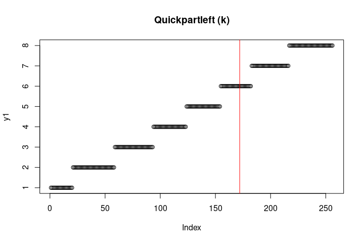

```r
n <- getOption("greensort_example_size")
k <- round(c(0.33, 0.67)*n)
x <- testdb$func$tielog2(n)
#par(mfrow=c(2, 2))
y1 <- x[]; r1 <- Quickpartleft(y1,  k[2]) ; plot(y1, main="Quickpartleft (k)"); abline(v=k[2], col="red")
```

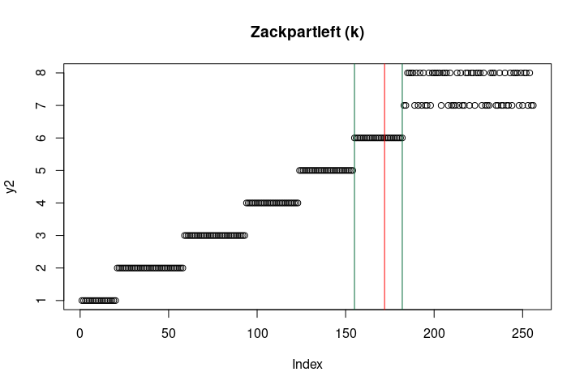

```r
y2 <- x[]; r2 <-  Zackpartleft(y2,  k[2]) ; plot(y2, main="Zackpartleft (k)"); abline(v=k[2], col="red", abline(v=r2, col=greensort_color))
```

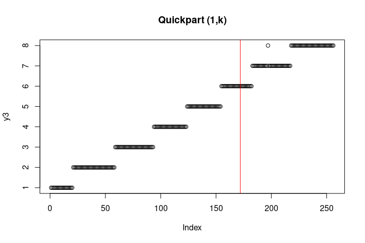

```r
y3 <- x[]; r3 <- Quickpart(y3, c(1, k[2])); plot(y3, main="Quickpart (1,k)"); abline(v=k[2], col="red")
```

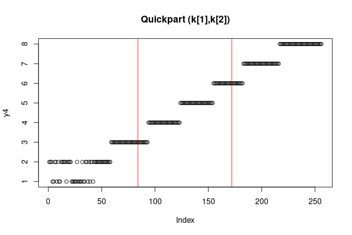

```r
y4 <- x[]; r4 <- Quickpart(y4,          k); plot(y4, main="Quickpart (k[1],k[2])"); abline(v=k   , col="red")
```

```r
#par(mfrow=c(1,1))
rm(y1,y2,y3,y4)
```

```r
list(r1, r2, r3, r4)
```

```
#> [[1]]
#> [1] 6
#> attr(,"perf")
#>                 n b p t size      secs base core unco dram
#> Quickpartleft 256 8 1 1    1 6.883e-06    0    0    0    0
#>
#> [[2]]
#> [1] 155 182
#> attr(,"perf")
#>                n b p t size      secs base core unco dram
#> Zackpartleft 256 8 1 1    1 6.442e-06    0    0    0    0
#>
#> [[3]]
#>             n b p t size      secs base core unco dram
#> Quickpart 256 8 1 1    1 7.173e-06    0    0    0    0
#>
#> [[4]]
#>             n b p t size      secs base core unco dram
#> Quickpart 256 8 1 1    1 6.302e-06    0    0    0    0
```

Let’s now compare four algorithms: `Dotnetpart` is a (suboptimal) real-world implementation, `Quickpart` is an efficient prior-art algorithm, `Zuckpart` is a new symmetric algorithm, and `ZuckpartB` is a version tuned to avoid branch-misprediction.

```r
n <- 2^26
k <- round(c(0.33, 0.67)*n)
x <- testdb$func$tiesqrt(n)
y <- x[]; r1 <- perf(Dotnetpart(y, k))
y <- x[]; r2 <- perf( Quickpart(y, k))
y <- x[]; r3 <- perf( Zuckpart (y, k))
y <- x[]; r4 <- perf( ZuckpartB(y, k))
rm(x,y)
rbind(r1,r2,r3,r4)
```

```
#>            %RAM   runTime  lifeTime   cpuTime  bEnergy cdEnergy bcdEnergy pcdEnergy
#> Dotnetpart    1 2.0710191 2.0710191 2.0710191 56.16189 1.119464  57.28135  8.139700
#> Quickpart     1 1.7200236 1.7200236 1.7200236 42.14668 0.564760  42.71144  5.833095
#> Zuckpart      1 1.3511031 1.3511031 1.3511031 33.60128 0.826220  34.42750  5.026379
#> ZuckpartB     1 0.5788987 0.5788987 0.5788987 14.57588 0.765463  15.34134  2.587447
#>            cdFootprint bcdFootprint pcdFootprint tFootprint
#> Dotnetpart    1.119464     57.28135     8.139700  2.0710191
#> Quickpart     0.564760     42.71144     5.833095  1.7200236
#> Zuckpart      0.826220     34.42750     5.026379  1.3511031
#> ZuckpartB     0.765463     15.34134     2.587447  0.5788987
```

## Generating string data

The data generators of `testdb` can be used to generate string data:

```r
num2str(testdb$func$stable(7))
```

```
#> [1] "1.0" "2.0" "3.0" "0.0" "2.5" "3.5" "1.5"
```

These are suitable for creating string data with similar characteristics as the numeric data, but these are not natural strings. The *greeNsort<sup>®</sup>* package has `vtestdb` with elements of natural language, for example variants of Kafka’s “Die Verwandlung”:

```r
subset(vtestdb, major == "K", c("name","relentropy","monotAscFrac", "strictAscFrac","spearman"))
```

```
#>                name relentropy monotAscFrac strictAscFrac     spearman
#> KP       KafkaParts  0.9970259    0.5000000     0.5000000 -0.147559697
#> KPa  KafkaParts_asc  0.9970259    1.0000000     0.9900000  1.000000000
#> KPd KafkaParts_desc  0.9970259    0.0100000     0.0000000 -0.999988352
#> KPp KafkaParts_perm  0.9970259    0.5100000     0.5100000 -0.010145603
#> KW       KafkaWords  0.6710723    0.5083268     0.5077003  0.022539129
#> KWa  KafkaWords_asc  0.6710723    1.0000000     0.2069434  1.000000000
#> KWd KafkaWords_desc  0.6710723    0.7930566     0.0000000 -0.999787047
#> KWp KafkaWords_perm  0.6710723    0.5011746     0.4957974  0.003540487
```

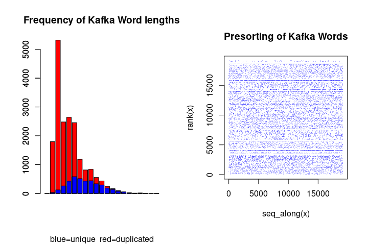

```r
x <- KafkaWords()
par(mfrow=c(1,2))
barplot(tabulate(nchar(x)), col="red", main="Frequency of Kafka Word lengths", sub="blue=unique  red=duplicated")
barplot(tabulate(nchar(unique(x))), add=TRUE, col="blue")
par(pty="s")
plot(seq_along(x), rank(x), col=rgb(0,0,1,0.3), pch=".", main="Presorting of Kafka Words")
```

```r
par(mfrow=c(1,1), pty="m")
```

Finally note that *VFrogsort* uses a reserved rare character `BUFFER_CHAR` to mark empty buffers. The R-function `string_check()` returns the first occurence of `BUFFER_CHAR` in its input vector of strings (and 0 for strings that do not contain `BUFFER_CHAR`, hopefully)

```r
string_check(KafkaParts())
```

```
#>   [1] 0 0 0 0 0 0 0 0 0 0 0 0 0 0 0 0 0 0 0 0 0 0 0 0 0 0 0 0 0 0 0 0 0 0 0 0 0 0 0 0
#>  [41] 0 0 0 0 0 0 0 0 0 0 0 0 0 0 0 0 0 0 0 0 0 0 0 0 0 0 0 0 0 0 0 0 0 0 0 0 0 0 0 0
#>  [81] 0 0 0 0 0 0 0 0 0 0 0 0 0 0 0 0 0 0 0 0 0
```

## Sorting string data

The Kafka datasets are small. The bible has a larger corpus of words:

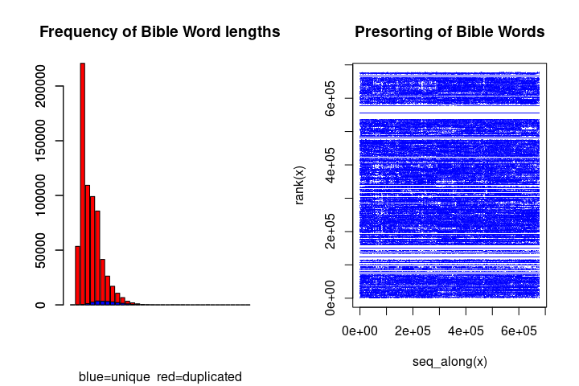

```r
x <- BibleWords()
par(mfrow=c(1,2))
barplot(tabulate(nchar(x)), col="red", main="Frequency of Bible Word lengths", sub="blue=unique  red=duplicated")
barplot(tabulate(nchar(unique(x))), add=TRUE, col="blue")
plot(seq_along(x), rank(x), col=rgb(0,0,1,0.3), pch=".", main="Presorting of Bible Words")
```

```r
par(mfrow=c(1,1))
```

```r
A <- c("WQuick2","UZack","VKnuth", "VFrog1")
M <- do.call("rbind", lapply(A, function(a){
    y <- x[]
    Sys.sleep(1)
    sperf(algodb[[a,"func"]](y))
}))
t(t(M)/apply(M, 2, min))
```

```
#>                 %RAM  runTime bcdEnergy bcdFootprint tFootprint
#> WQuicksort2 1.598839 2.053743  2.046349     2.339264   2.391906
#> UZacksort   1.598839 1.000000  1.000000     1.143140   1.164657
#> VKnuthsort  1.333330 1.373663  1.336252     1.273858   1.334170
#> VFrogsort1  1.000000 1.372798  1.398637     1.000000   1.000000
```

*WQuicksort2* is an indirekt *Quicksort2* sorting and stabilizing pointers to strings. *UZacksort* is an indirect *Zacksort* which does not stablize and hence exploits duplicates. *VKnuthsort* is a *Knuthsort* that sorts (and moves) strings directly. *VFrogsort1* is a *Frogsort1* that sorts (and moves) strings directly.

Given the huge number of duplicated words in the bible, *UZacksort* appears as a clear winner here, and the stabilized Quicksort is a clear loser. However, note that the *Footprints* of *VFrogsort1* can compete with *UZacksort*: *VFrogsort1* has the lowest `%RAM` because elements are small and the Quicksorts need extra memory for pointers.

Now let’s turn to longer sequences of words, 5-grams:

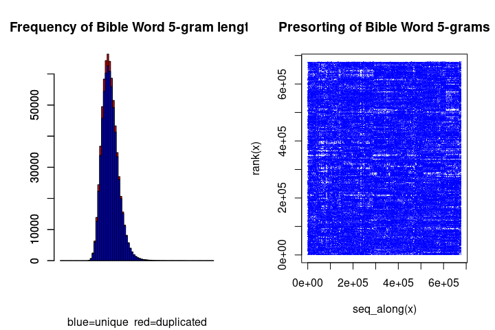

```r
shift <- function(x, i){
  if (i>0)
    x <- c(x[-(1:i)], x[1:i])
  x
}
x <- BibleWords()
x <- paste(x, shift(x, 1), shift(x, 2), shift(x, 3), shift(x, 4))
par(mfrow=c(1,2))
barplot(tabulate(nchar(x)), col="red", main="Frequency of Bible Word 5-gram lengths", sub="blue=unique  red=duplicated")
barplot(tabulate(nchar(unique(x))), add=TRUE, col="blue")
plot(seq_along(x), rank(x), col=rgb(0,0,1,0.3), pch=".", main="Presorting of Bible Word 5-grams")
```

```r
par(mfrow=c(1,1))
```

5-grams have very few duplicates. Let’s sort these:

```r
A <- c("WQuick2","UZack","VKnuth", "VFrog1")
M <- do.call("rbind", lapply(A, function(a){
    y <- x[]
    Sys.sleep(1)
    sperf(algodb[[a,"func"]](y))
}))
t(t(M)/apply(M, 2, min))
```

```
#>                 %RAM  runTime bcdEnergy bcdFootprint tFootprint
#> WQuicksort2 1.000000 1.556774  1.447485     1.106190   1.206612
#> UZacksort   1.000000 1.604910  1.540417     1.177210   1.243921
#> VKnuthsort  1.562924 1.000000  1.000000     1.194411   1.211379
#> VFrogsort1  1.172195 1.100672  1.116309     1.000000   1.000000
```

Now the Quicksorts have the lowest `%RAM`, but *VKnuthsort* wins on `runTime` and `bcdEnergy` and *VFrogsort1* wins on the Footprints.

Finally let’s look at the dictionary data:

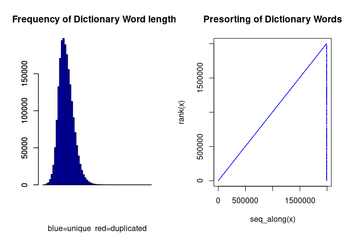

```r
x <- DictWords()
par(mfrow=c(1,2))
barplot(tabulate(nchar(x)), col="red", main="Frequency of Dictionary Word lengths", sub="blue=unique  red=duplicated")
barplot(tabulate(nchar(unique(x))), add=TRUE, col="blue")
plot(seq_along(x), rank(x), col=rgb(0,0,1,0.3), pch=".", main="Presorting of Dictionary Words")
```

```r
par(mfrow=c(1,1))
```

Dictionary words have no duplicates and are (almost) sorted.

```r
A <- c("WQuick2","UZack","VKnuth", "VFrog1")
M <- do.call("rbind", lapply(A, function(a){
    y <- x[]
    Sys.sleep(1)
    sperf(algodb[[a,"func"]](y))
}))
t(t(M)/apply(M, 2, min))
```

```
#>                 %RAM  runTime bcdEnergy bcdFootprint tFootprint
#> WQuicksort2 1.004157 1.567309  1.351985     1.357605   1.573824
#> UZacksort   1.004157 1.700241  1.700984     1.708055   1.707309
#> VKnuthsort  1.333332 1.036939  1.223744     1.631658   1.382584
#> VFrogsort1  1.000000 1.000000  1.000000     1.000000   1.000000
```

## Sorting matrix data

So far we only sorted keys. What happens if we sort records with a key? What happens if we vary the size of the payload? We implemented some algorithms to sort 32bit-integer matrix-columns by keys in the first matrix row, so all rows after the first row contain payload data. The following algorithms are available for matrix data:

```r
A <- algodb$label[algodb$matrix]
split(A, algodb[A,"task"])
```

```
#> $sort
#> [1] "MIns" "NIns"
#>
#> $SORT
#> [1] "MKnuth" "NKnuth" "MFrog2" "NFrog2"
```

So here is a small example

```
#>                n b p t size      secs base core unco dram
#> MInsertionsort 6 8 1 1    1 1.773e-06    0    0    0    0
#>      [,1] [,2] [,3] [,4] [,5] [,6]
#> [1,]    1    1    1    2    2    2
#> [2,]    3    2    1    3    2    1
```

Here are some stored measurements for a subset of those (AMD® Ryzen 7 pro 6850, 8 physical cores):

This was measured with the following code, try it out on your machine:

```r
A <- c("MKnuth", "NKnuth", "MFrog1", "NFrog1", "MFrog2", "NFrog2")
names(A) <- A
D <- c(1,2,5,50)
names(D) <- D
n <- 2^22
# we collect the results in a A x D matrix of list elements
x <- rbind(sample(n))
M <- do.call("cbind", lapply(D, function(d){
  x <- do.call("rbind", rep(list(x[1,]), d))
  cat("d=", d, "\n", sep="")
  P <- lapply(A, function(a){
    cat("  a=", a, "\n", sep="")
      y <- x[]
    Sys.sleep(1)  # cool down CPU for fair TURBO
    if (a %in% c("MFrog1", "NFrog1"))
    perf(algodb[[sub("1","2",a),"func"]](y, p=0.5))
    else
    perf(algodb[[a,"func"]](y))
  })
  P
}))
rm(x)
T <- function(x)cbind(x, "ALL"=rowMeans(cbind(x, x[,"permut"])), ASC=rowMeans(x[,c("permut","asclocal","ascglobal","ascall")]))
runTime <- apply(M,1:2,function(i)i[[1]][,"runTime"])
Energy <- apply(M,1:2,function(i)i[[1]][,"bcdEnergy"])
eFootprint <- apply(M,1:2,function(i)i[[1]][,"bcdFootprint"])
dput(runTime)
dput(Energy)
dput(eFootprint)
```

Note that *Frogsort1* is a special case of *Frogsort2* with `p=0.5`. Let’s look at runTime normalized by *Knuthsort* at randomly permuted data:

```r
round(runTime/runTime["MKnuth",1], 3)
```

```
#>            1     2     5    50
#> MKnuth 1.000 1.115 1.182 4.892
#> NKnuth 0.573 0.801 1.027 2.300
#> MFrog1 0.917 0.966 1.039 4.312
#> NFrog1 0.596 0.857 0.985 2.340
#> MFrog2 0.918 1.030 1.061 5.893
#> NFrog2 0.463 0.804 0.879 2.250
```

```r
round(Energy/Energy["MKnuth",1], 3)
```

```
#>            1     2     5    50
#> MKnuth 1.000 1.036 1.815 6.941
#> NKnuth 0.515 0.617 1.450 3.025
#> MFrog1 0.868 0.823 1.561 5.566
#> NFrog1 0.563 0.923 1.353 2.854
#> MFrog2 0.894 1.564 1.538 6.832
#> NFrog2 0.447 1.183 1.153 2.446
```

[^1]: Note that the `Z*part` and `Z*partB` functions do not return the tie-extended range of the sorted interval, but can be modified at minor cost to do so